# module 15

Emiley Garcia-Zych

2023-12-17

# Module 15. Multiple Regression and ANCOVA

Install these packages in R: {curl}, {ggplot2}, {gridExtra}, {dplyr}, {car}

## Overview

Multiple linear regression and ANCOVA are pretty straightforward generalizations of the simple linear regression and ANOVA approach that we have considered previously (i.e., Model I regressions with our parameters estimated using the criterion of OLS). In multiple linear regression and ANCOVA, we are looking to model a response variable in terms of more than one predictor variable so we can evaluate the effects of several different explanatory variables. When we do multiple linear regression, we are, essentially, looking at the relationship between each of two or more continuous predictor variables and a continuous response variable while holding the effect of all other predictor variables constant. When we do ANCOVA, we are effectively looking at the relationship between one or more continuous predictor variables and a continuous response variable within each of one or more categorical groups.

## Multiple Regression - Continuous Response Variable and More than One Continuous Predictor Variables

```r
R = matrix(cbind(1, 0.8, -0.5, 0, 0.8, 1, -0.3, 0.3, -0.5, -0.3, 1, 0.6, 0,
    0.3, 0.6, 1), nrow = 4)
```

```r
n <- 1000
k <- 4
M <- NULL
V <- NULL
mu <- c(15, 40, 5, 23)  # vector of variable means
s <- c(5, 20, 4, 15)  # vector of variable SDs
for (i in 1:k) {
    V <- rnorm(n, mu[i], s[i])
    M <- cbind(M, V)
}
M <- matrix(M, nrow = n, ncol = k)
orig <- as.data.frame(M)
names(orig) = c("Y", "X1", "X2", "X3")
head(orig)
```

```
##           Y       X1         X2       X3
## 1 18.737488 72.67060  0.5963042 31.27612
## 2 21.050876 66.94198  5.5997552 29.52467
## 3 11.554166 45.20285  3.1393541 12.76626
## 4  6.558669 15.13085 10.6413807 17.28482
## 5  8.751015 70.53001  4.8076809 52.34275
## 6 20.386886 12.48727 -5.4464872 23.84487
```

```r
cor(orig)
```

```
##               Y           X1          X2           X3
## Y   1.000000000  0.011393816 0.022738503 -0.006347454
## X1  0.011393816  1.000000000 0.008152825 -0.041035557
## X2  0.022738503  0.008152825 1.000000000  0.004783245
## X3 -0.006347454 -0.041035557 0.004783245  1.000000000
```

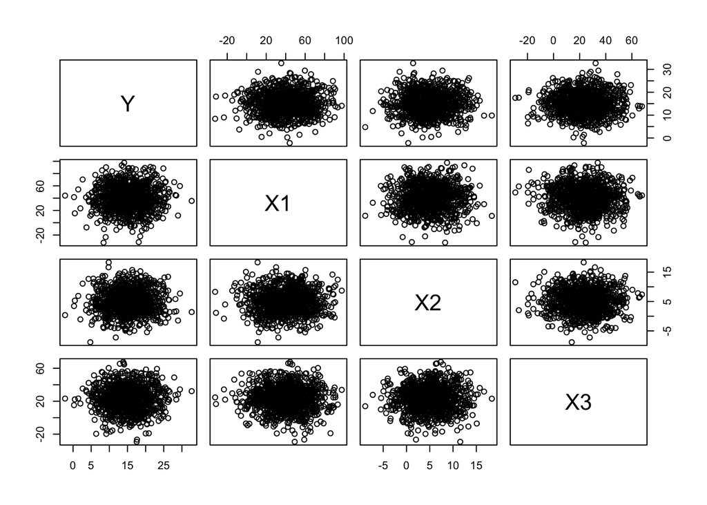

```r
plot(orig)  # does quick bivariate plots for each pair of variables; using `pairs(orig)` would do the same
```

```r
ms <- apply(orig, 2, FUN = "mean")  # returns a vector of means, where we are taking this across dimension 2 of the array 'orig'
ms
```

```
##         Y        X1        X2        X3
## 15.137965 40.110359  4.973347 23.426397
```

```r
sds <- apply(orig, 2, FUN = "sd")
sds
```

```
##         Y        X1        X2        X3
##  4.881222 20.513277  4.044227 15.211315
```

```r
normalized <- sweep(orig, 2, STATS = ms, FUN = "-")  # 2nd dimension is columns, removing array of means, function = subtract
normalized <- sweep(normalized, 2, STATS = sds, FUN = "/")  # 2nd dimension is columns, scaling by array of sds, function = divide
head(normalized)  # now a dataframe of Z scores
```

```
##            Y         X1          X2          X3
## 1  0.7374225  1.5872765 -1.08229393  0.51604480
## 2  1.2113587  1.3080124  0.15488946  0.40090365
## 3 -0.7342012  0.2482536 -0.45348412 -0.70080307
## 4 -1.7576126 -1.2177239  1.40151209 -0.40375076
## 5 -1.3084738  1.4829251 -0.04096361  1.90097677
## 6  1.0753294 -1.3465957 -2.57647087  0.02751097
```

```r
M <- as.matrix(normalized)  # redefine M as our matrix of normalized variables
```

```r
U = chol(R)
newM = M %*% U
new = as.data.frame(newM)
names(new) = c("Y", "X1", "X2", "X3")
cor(new)  # note that is correlation matrix is what we are aiming for!
```

```
##              Y         X1         X2         X3
## Y   1.00000000  0.8024595 -0.4833699 0.01573868
## X1  0.80245955  1.0000000 -0.2834446 0.30118010
## X2 -0.48336994 -0.2834446  1.0000000 0.60557972
## X3  0.01573868  0.3011801  0.6055797 1.00000000
```

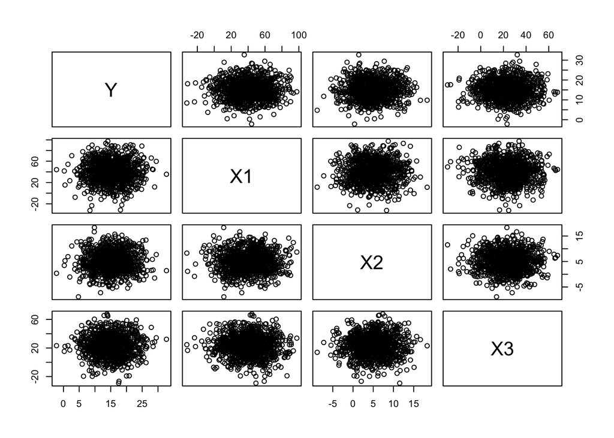

```r
plot(orig)
```

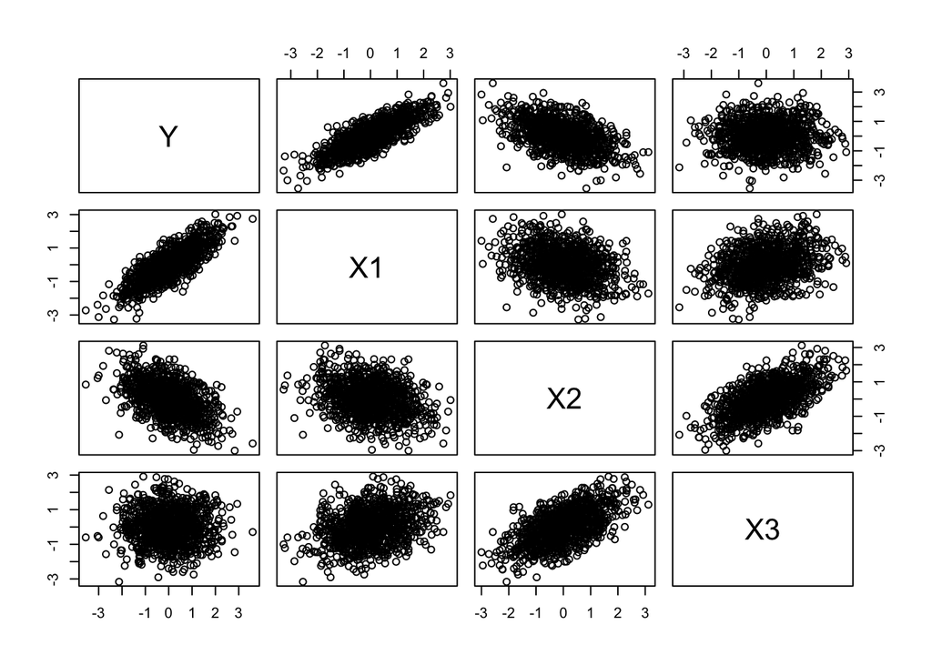

```r
plot(new)
```

```r
df <- sweep(new, 2, STATS = sds, FUN = "*")  # scale back out to original mean...
df <- sweep(df, 2, STATS = ms, FUN = "+")  # and standard deviation
head(df)
```

```
##           Y       X1         X2        X3
## 1 18.737488 71.74807  0.8323082  30.33110
## 2 21.050876 76.08848  3.9378365  38.56822
## 3 11.554166 31.11716  5.0667234  14.54609
## 4  6.558669 -3.72086 12.5235499  23.33797
## 5  8.751015 36.88928  8.4779884  52.16045
## 6 20.386886 41.18333 -6.9639042 -10.38412
```

```r
cor(df)
```

```
##              Y         X1         X2         X3
## Y   1.00000000  0.8024595 -0.4833699 0.01573868
## X1  0.80245955  1.0000000 -0.2834446 0.30118010
## X2 -0.48336994 -0.2834446  1.0000000 0.60557972
## X3  0.01573868  0.3011801  0.6055797 1.00000000
```

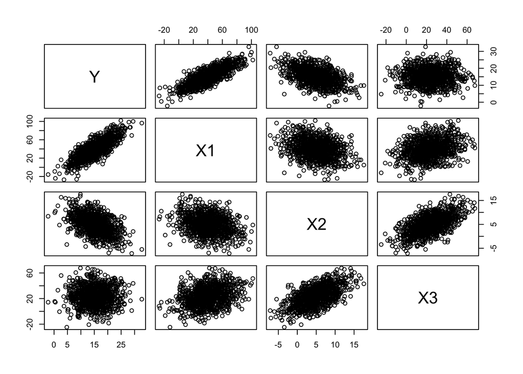

```r
plot(df)  # note the change to the axis scales; using `pairs(d)` would produce the same plot
```

## Challenge 1

Start off by making some bivariate scatterplots in {ggplot2}. Then, using simple linear regression as implemented with lm(), how does the response variable (Y) vary with each predictor variable (X1, X2, X3)? Are the β1 coefficients significant? How much of the variation in Y does each predictor explain in a simple bivariate linear model?

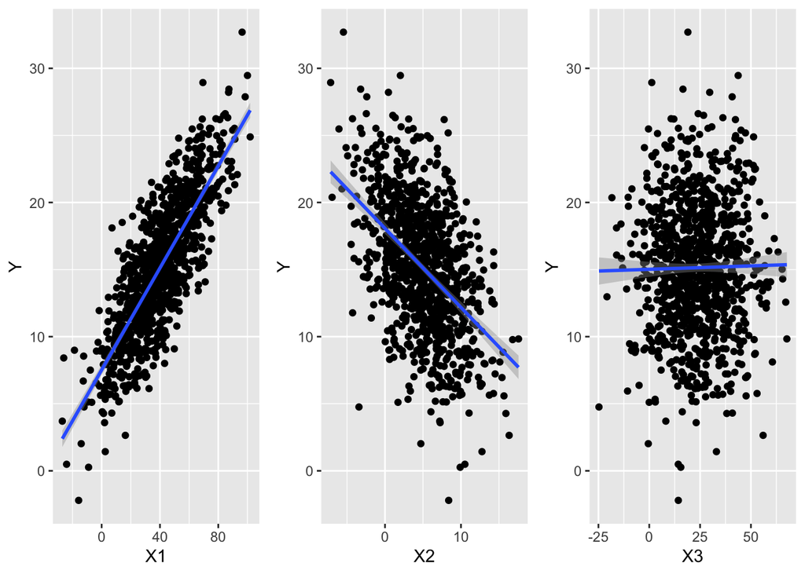

```r
library(ggplot2)
require(gridExtra)
g1 <- ggplot(data = df, aes(x = X1, y = Y)) + geom_point() + geom_smooth(method = "lm",
    formula = y ~ x)
g2 <- ggplot(data = df, aes(x = X2, y = Y)) + geom_point() + geom_smooth(method = "lm",
    formula = y ~ x)
g3 <- ggplot(data = df, aes(x = X3, y = Y)) + geom_point() + geom_smooth(method = "lm",
    formula = y ~ x)
grid.arrange(g1, g2, g3, ncol = 3)
```

```r
m1 <- lm(data = df, formula = Y ~ X1)
summary(m1)
```

```
##
## Call:
## lm(formula = Y ~ X1, data = df)
##
## Residuals:
##     Min      1Q  Median      3Q     Max
## -7.9643 -1.9365 -0.0683  2.0198  9.2354
##
## Coefficients:
##             Estimate Std. Error t value Pr(>|t|)
## (Intercept)  7.52049    0.20160   37.30   <2e-16 ***
## X1           0.18991    0.00447   42.48   <2e-16 ***
## ---
## Signif. codes:  0 '***' 0.001 '**' 0.01 '*' 0.05 '.' 0.1 ' ' 1
##
## Residual standard error: 2.914 on 998 degrees of freedom
## Multiple R-squared:  0.6439, Adjusted R-squared:  0.6436
## F-statistic:  1805 on 1 and 998 DF,  p-value: < 2.2e-16
```

```r
m2 <- lm(data = df, formula = Y ~ X2)
summary(m2)
```

```
##
## Call:
## lm(formula = Y ~ X2, data = df)
##
## Residuals:
##      Min       1Q   Median       3Q      Max
## -15.3331  -3.0208  -0.0751   2.9715  12.6962
##
## Coefficients:
##             Estimate Std. Error t value Pr(>|t|)
## (Intercept) 18.06729    0.21559   83.80   <2e-16 ***
## X2          -0.58900    0.03377  -17.44   <2e-16 ***
## ---
## Signif. codes:  0 '***' 0.001 '**' 0.01 '*' 0.05 '.' 0.1 ' ' 1
##
## Residual standard error: 4.275 on 998 degrees of freedom
## Multiple R-squared:  0.2336, Adjusted R-squared:  0.2329
## F-statistic: 304.3 on 1 and 998 DF,  p-value: < 2.2e-16
```

```r
m3 <- lm(data = df, formula = Y ~ X3)
summary(m3)
```

```
##
## Call:
## lm(formula = Y ~ X3, data = df)
##
## Residuals:
##      Min       1Q   Median       3Q      Max
## -17.2939  -3.1791  -0.0667   3.3740  17.5802
##
## Coefficients:
##              Estimate Std. Error t value Pr(>|t|)
## (Intercept) 15.018647   0.285342  52.634   <2e-16 ***
## X3           0.005093   0.010243   0.497    0.619
## ---
## Signif. codes:  0 '***' 0.001 '**' 0.01 '*' 0.05 '.' 0.1 ' ' 1
##
## Residual standard error: 4.883 on 998 degrees of freedom
## Multiple R-squared:  0.0002477,  Adjusted R-squared:  -0.000754
## F-statistic: 0.2473 on 1 and 998 DF,  p-value: 0.6191
```

```r
m <- lm(data = df, formula = Y ~ X1 + X2 + X3)
coef(m)
```

```
## (Intercept)          X1          X2          X3
##  9.79576062  0.18174710 -0.26007681 -0.02792937
```

```r
summary(m)
```

```
##
## Call:
## lm(formula = Y ~ X1 + X2 + X3, data = df)
##
## Residuals:
##     Min      1Q  Median      3Q     Max
## -7.5343 -1.7802  0.0145  1.6927  7.7685
##
## Coefficients:
##              Estimate Std. Error t value Pr(>|t|)
## (Intercept)  9.795761   0.241465  40.568  < 2e-16 ***
## X1           0.181747   0.005290  34.359  < 2e-16 ***
## X2          -0.260077   0.032636  -7.969 4.35e-15 ***
## X3          -0.027929   0.008717  -3.204   0.0014 **
## ---
## Signif. codes:  0 '***' 0.001 '**' 0.01 '*' 0.05 '.' 0.1 ' ' 1
##
## Residual standard error: 2.596 on 996 degrees of freedom
## Multiple R-squared:  0.7181, Adjusted R-squared:  0.7172
## F-statistic: 845.6 on 3 and 996 DF,  p-value: < 2.2e-16
```

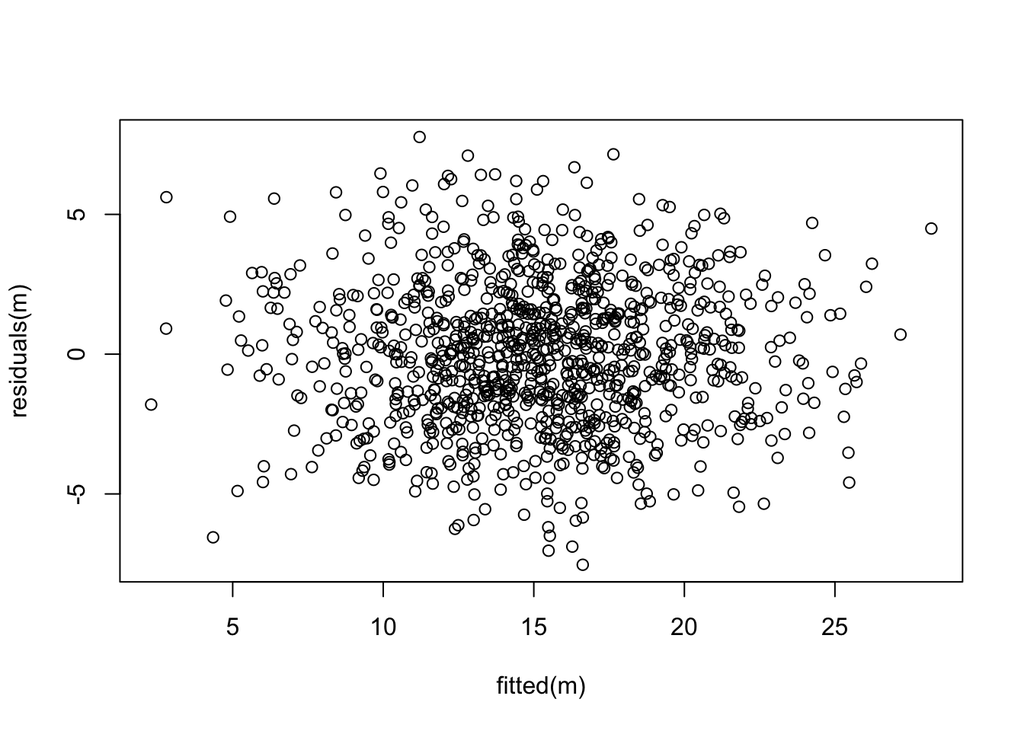

```r
# let's check if our residuals are random normal...
plot(fitted(m), residuals(m))
```

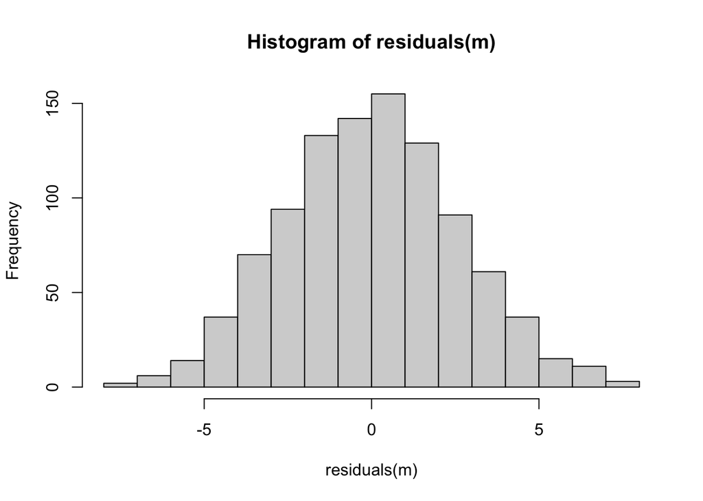

```r
hist(residuals(m))
```

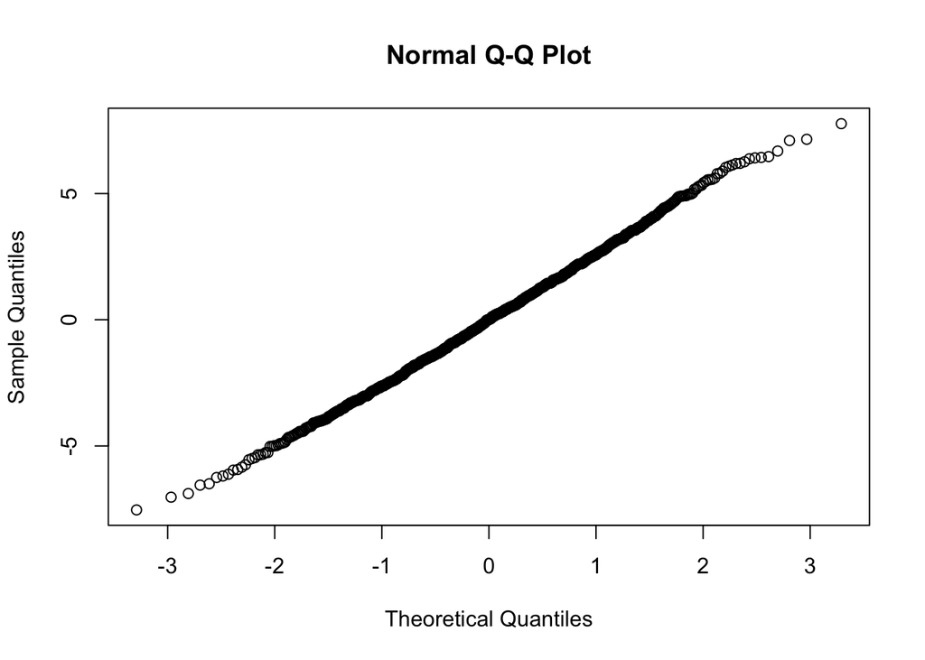

```r
qqnorm(residuals(m))
```

```r
f <- (summary(m)$r.squared * (nrow(df) - (ncol(df) - 1) - 1))/((1 - summary(m)$r.squared) *
    (ncol(df) - 1))
f
```

```
## [1] 845.566
```

## Challenge 2

Load up the “zombies.csv” dataset again and run a linear model of height as a function of both weight and age. Is the overall model significant? Are both predictor variables significant when the other is controlled for?

```r
library(curl)
f <- curl("https://raw.githubusercontent.com/fuzzyatelin/fuzzyatelin.github.io/master/AN588_Fall21/zombies.csv")
z <- read.csv(f, header = TRUE, sep = ",", stringsAsFactors = TRUE)
head(z)
```

```
##   id first_name last_name gender   height   weight zombies_killed
## 1  1      Sarah    Little Female 62.88951 132.0872              2
## 2  2       Mark    Duncan   Male 67.80277 146.3753              5
## 3  3    Brandon     Perez   Male 72.12908 152.9370              1
## 4  4      Roger   Coleman   Male 66.78484 129.7418              5
## 5  5      Tammy    Powell Female 64.71832 132.4265              4
## 6  6    Anthony     Green   Male 71.24326 152.5246              1
##   years_of_education                           major      age
## 1                  1                medicine/nursing 17.64275
## 2                  3 criminal justice administration 22.58951
## 3                  1                       education 21.91276
## 4                  6                  energy studies 18.19058
## 5                  3                       logistics 21.10399
## 6                  4                  energy studies 21.48355
```

```r
m <- lm(data = z, height ~ weight + age)
summary(m)
```

```
##
## Call:
## lm(formula = height ~ weight + age, data = z)
##
## Residuals:
##     Min      1Q  Median      3Q     Max
## -5.2278 -1.1782 -0.0574  1.1566  5.4117
##
## Coefficients:
##              Estimate Std. Error t value Pr(>|t|)
## (Intercept) 31.763388   0.470797   67.47   <2e-16 ***
## weight       0.163107   0.002976   54.80   <2e-16 ***
## age          0.618270   0.018471   33.47   <2e-16 ***
## ---
## Signif. codes:  0 '***' 0.001 '**' 0.01 '*' 0.05 '.' 0.1 ' ' 1
##
## Residual standard error: 1.64 on 997 degrees of freedom
## Multiple R-squared:  0.8555, Adjusted R-squared:  0.8553
## F-statistic:  2952 on 2 and 997 DF,  p-value: < 2.2e-16
```

## Challenge 3

```r
#'weight' not found
```

Challenge 4 Load in the “KamilarAndCooper.csv”” dataset we have used previously

Reduce the dataset to the following variables: Family, Brain_Size_Female_Mean, Body_mass_female_mean, MeanGroupSize, DayLength_km, HomeRange_km2, and Move

Fit a Model I least squares multiple linear regression model using log(HomeRange_km2) as the response variable and log(Body_mass_female_mean), log(Brain_Size_Female_Mean), MeanGroupSize, and Move as predictor variables, and view a model summary.

```r
library(dplyr)
f <- curl("https://raw.githubusercontent.com/fuzzyatelin/fuzzyatelin.github.io/master/AN588_Fall21/KamilarAndCooperData.csv")
d <- read.csv(f, header = TRUE, sep = ",", stringsAsFactors = TRUE)
head(d)
```

```
##               Scientific_Name          Family          Genus      Species
## 1 Allenopithecus_nigroviridis Cercopithecidae Allenopithecus nigroviridis
## 2         Allocebus_trichotis Cercopithecidae      Allocebus    trichotis
## 3           Alouatta_belzebul        Atelidae       Alouatta     belzebul
## 4             Alouatta_caraya        Atelidae       Alouatta       caraya
## 5            Alouatta_guariba        Atelidae       Alouatta      guariba
## 6           Alouatta_palliata        Atelidae       Alouatta     palliata
##   Brain_Size_Species_Mean Brain_Size_Female_Mean   Brain_size_Ref
## 1                   58.02                  53.70 Isler et al 2008
## 2                      NA                     NA
## 3                   52.84                  51.19 Isler et al 2008
## 4                   52.63                  47.80 Isler et al 2008
## 5                   51.70                  49.08 Isler et al 2008
## 6                   49.88                  48.04 Isler et al 2008
##   Body_mass_male_mean Body_mass_female_mean Mass_Dimorphism
```

[output cut: 62 more lines]

```r
d <- select(d, Brain_Size_Female_Mean, Family, Body_mass_female_mean, MeanGroupSize,
    DayLength_km, HomeRange_km2, Move)
```

```r
m <- lm(data = d, log(HomeRange_km2) ~ log(Body_mass_female_mean) + log(Brain_Size_Female_Mean) +
    MeanGroupSize + Move)
summary(m)
```

```
##
## Call:
## lm(formula = log(HomeRange_km2) ~ log(Body_mass_female_mean) +
##     log(Brain_Size_Female_Mean) + MeanGroupSize + Move, data = d)
##
## Residuals:
##     Min      1Q  Median      3Q     Max
## -3.7978 -0.6473 -0.0038  0.8807  2.1598
##
## Coefficients:
##                              Estimate Std. Error t value Pr(>|t|)
## (Intercept)                 -6.955853   1.957472  -3.553 0.000865 ***
## log(Body_mass_female_mean)   0.315276   0.468439   0.673 0.504153
## log(Brain_Size_Female_Mean)  0.614460   0.591100   1.040 0.303771
## MeanGroupSize                0.034026   0.009793   3.475 0.001095 **
## Move                         0.025916   0.019559   1.325 0.191441
## ---
## Signif. codes:  0 '***' 0.001 '**' 0.01 '*' 0.05 '.' 0.1 ' ' 1
##
## Residual standard error: 1.127 on 48 degrees of freedom
##   (160 observations deleted due to missingness)
## Multiple R-squared:  0.6359, Adjusted R-squared:  0.6055
## F-statistic: 20.95 on 4 and 48 DF,  p-value: 4.806e-10
```

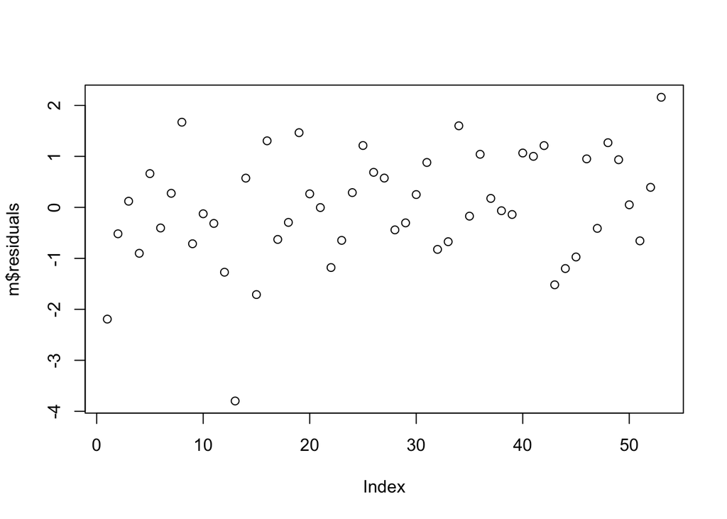

```r
plot(m$residuals)
```

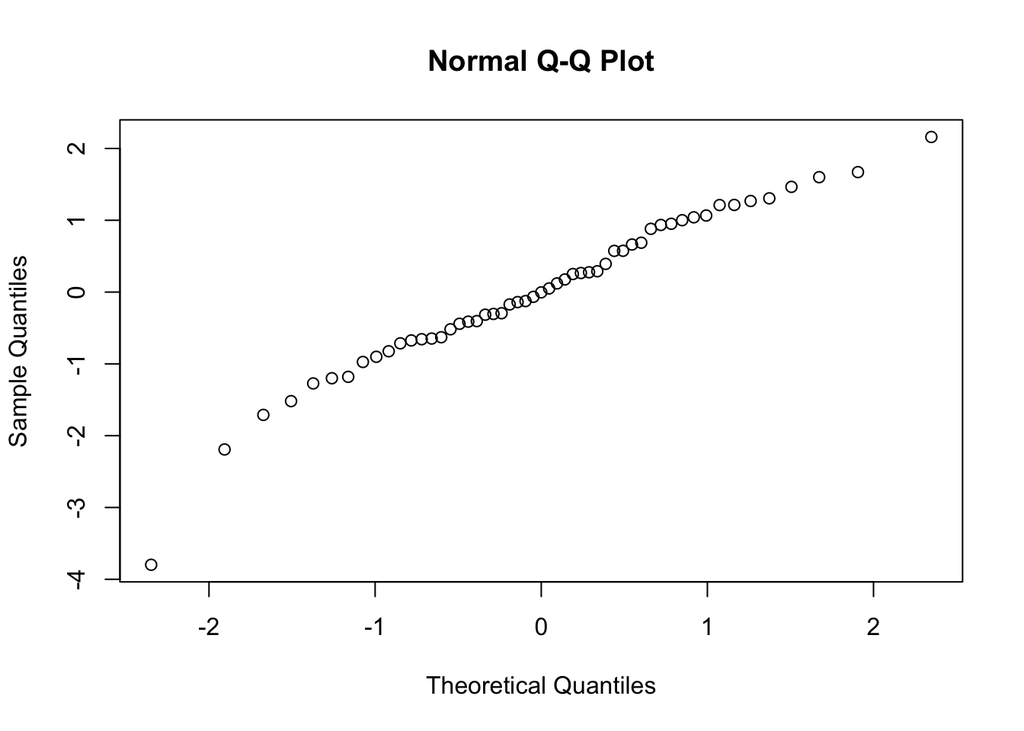

```r
qqnorm(m$residuals)
```

```r
shapiro.test(m$residuals)
```

```
##
##  Shapiro-Wilk normality test
##
## data:  m$residuals
## W = 0.96517, p-value = 0.1242
```

```r
m <- lm(data = d, log(HomeRange_km2) ~ log(Body_mass_female_mean) + log(Brain_Size_Female_Mean) +
    MeanGroupSize)
summary(m)
```

```
##
## Call:
## lm(formula = log(HomeRange_km2) ~ log(Body_mass_female_mean) +
##     log(Brain_Size_Female_Mean) + MeanGroupSize, data = d)
##
## Residuals:
##     Min      1Q  Median      3Q     Max
## -3.7982 -0.7310 -0.0140  0.8386  3.1926
##
## Coefficients:
##                              Estimate Std. Error t value Pr(>|t|)
## (Intercept)                 -5.354845   1.176046  -4.553 1.45e-05 ***
## log(Body_mass_female_mean)  -0.181627   0.311382  -0.583 0.560972
## log(Brain_Size_Female_Mean)  1.390536   0.398840   3.486 0.000721 ***
## MeanGroupSize                0.030433   0.008427   3.611 0.000473 ***
## ---
## Signif. codes:  0 '***' 0.001 '**' 0.01 '*' 0.05 '.' 0.1 ' ' 1
##
## Residual standard error: 1.228 on 103 degrees of freedom
##   (106 observations deleted due to missingness)
## Multiple R-squared:  0.6766, Adjusted R-squared:  0.6672
## F-statistic: 71.85 on 3 and 103 DF,  p-value: < 2.2e-16
```

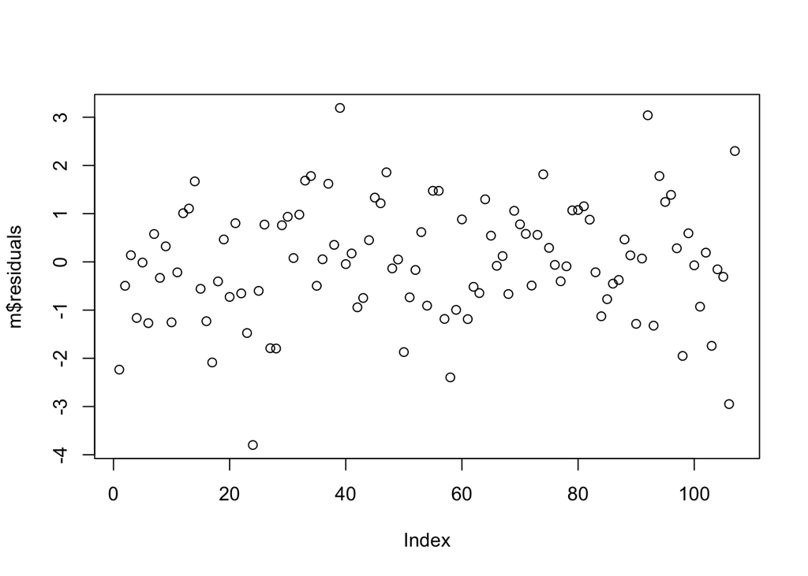

```r
plot(m$residuals)
```

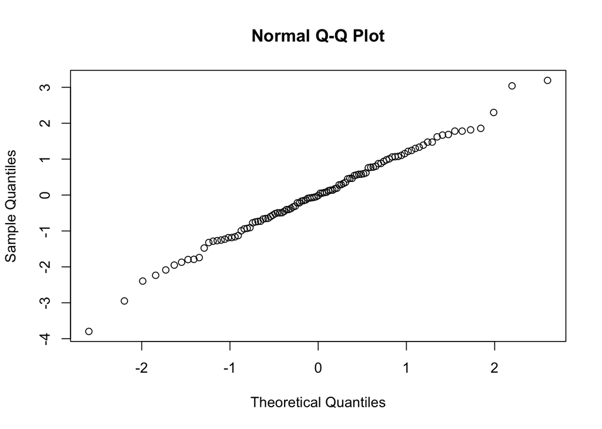

```r
qqnorm(m$residuals)
```

```r
shapiro.test(m$residuals)
```

```
##
##  Shapiro-Wilk normality test
##
## data:  m$residuals
## W = 0.99366, p-value = 0.9058
```